# Analysis of statsForAllRuns.tsv

```r
d<- read.table("statsForAllRuns.tsv", h=T, sep="\t", colClasses=c("character", "integer", "integer", "factor", "factor", rep("numeric", 14), rep("factor", 15)))
```

Working in percents rather than proportions

```r
d$rmsd_norm <- 100*d$rmsd_norm
```

Renaming balanced or not

```r
levels(d$balanced)[levels(d$balanced)=="n"] <- "unbalanced"
levels(d$balanced)[levels(d$balanced)=="y"] <- "balanced"
```

```r
summary(d)
```

```
    TreeId             numCalib     numCons           balanced
 Length:312         Min.   :10   Min.   : 0.0   unbalanced:156
 Class :character   1st Qu.:10   1st Qu.: 4.0   balanced  :156
 Mode  :character   Median :10   Median : 7.5
                    Mean   :10   Mean   : 7.5
                    3rd Qu.:10   3rd Qu.:11.0
                    Max.   :10   Max.   :15.0
 old_biased  correlation          rmsd         rmsd_norm
 y:312      Min.   :0.5347   Min.   :4.607   Min.   :33.80
            1st Qu.:0.5841   1st Qu.:4.938   1st Qu.:37.91
            Median :0.7662   Median :5.531   Median :42.57
            Mean   :0.7186   Mean   :5.961   Mean   :46.27
            3rd Qu.:0.8095   3rd Qu.:7.258   3rd Qu.:56.44
            Max.   :0.8238   Max.   :7.724   Max.   :61.66
    cor_bls          rmsd_bls       num_nodes      numInHPD
 Min.   :0.1302   Min.   :4.979   Min.   :101   Min.   :49.00
 1st Qu.:0.2110   1st Qu.:5.200   1st Qu.:101   1st Qu.:58.00
 Median :0.2403   Median :5.259   Median :101   Median :66.00
 Mean   :0.2506   Mean   :5.282   Mean   :101   Mean   :64.04
 3rd Qu.:0.3017   3rd Qu.:5.346   3rd Qu.:101   3rd Qu.:70.00
 Max.   :0.3375   Max.   :5.790   Max.   :101   Max.   :74.00
   fracInHPD        percent0       percent25       percent50
 Min.   :48.51   Min.   :3.517   Min.   : 7.13   Min.   : 8.252
 1st Qu.:57.43   1st Qu.:6.177   1st Qu.:10.06   1st Qu.:12.428
 Median :65.35   Median :6.363   Median :10.68   Median :13.060
 Mean   :63.40   Mean   :6.316   Mean   :10.88   Mean   :13.090
 3rd Qu.:69.31   3rd Qu.:6.506   3rd Qu.:11.84   3rd Qu.:13.900
 Max.   :73.27   Max.   :7.705   Max.   :13.18   Max.   :15.176
   percents75      percent100         rep         T_88.T_51..T_78.T_67
 Min.   :11.68   Min.   :16.00   Min.   : 0.000   0:134
 1st Qu.:13.85   1st Qu.:19.23   1st Qu.: 2.000   1:178
 Median :14.90   Median :19.93   Median : 5.000
 Mean   :15.06   Mean   :19.99   Mean   : 5.577
 3rd Qu.:16.34   3rd Qu.:20.82   3rd Qu.: 8.000
 Max.   :17.89   Max.   :23.12   Max.   :15.000
 T_64.T_66..T_56.T_14 T_100.T_0..T_90.T_32 T_90.T_29..T_69.T_52
 0: 84                0:132                0:120
 1:228                1:180                1:192


```

[output cut: 11 more lines]

```
 1:188               1:168                1:100




 T_69.T_72..T_8.T_33 T_74.T_40..T_51.T_28 T_91.T_16..T_98.T_6
 0:150               0:170                0:184
 1:162               1:142                1:128




 T_83.T_15..T_56.T_87 T_1.T_50..T_99.T_3
 0:182                0:224
 1:130                1: 88
```

### Link between constraints and their number in Fig. 2 of the paper

```r
colnames(d[20:34])
```

```
 [1] "T_88.T_51..T_78.T_67" "T_64.T_66..T_56.T_14" "T_100.T_0..T_90.T_32"
 [4] "T_90.T_29..T_69.T_52" "T_77.T_96..T_45.T_55" "T_54.T_79..T_96.T_86"
 [7] "T_87.T_14..T_27.T_62" "T_27.T_85..T_11.T_8"  "T_59.T_20..T_83.T_76"
[10] "T_99.T_9..T_65.T_51"  "T_69.T_72..T_8.T_33"  "T_74.T_40..T_51.T_28"
[13] "T_91.T_16..T_98.T_6"  "T_83.T_15..T_56.T_87" "T_1.T_50..T_99.T_3"
```

```r
constraint_numbers = c(1, 4, 6, 9, 12, 7, 10, 13, 15, 2, 3, 5, 8, 14, 11)
colnames(d)[20:34] <- paste("C", as.character(constraint_numbers), sep="_")
```

# Plots of the data

## Normalized RMSD of node ages

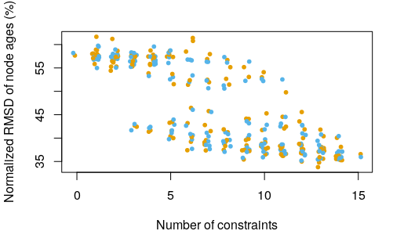

```r
col_cat <- c(y="#E69F00", n="#56B4E9")
plot(jitter(d$numCons), d$rmsd_norm, ylab="Normalized RMSD of node ages (%)", xlab="Number of constraints", col=col_cat[d$balanced], pch=20)
```

### Using ggplot

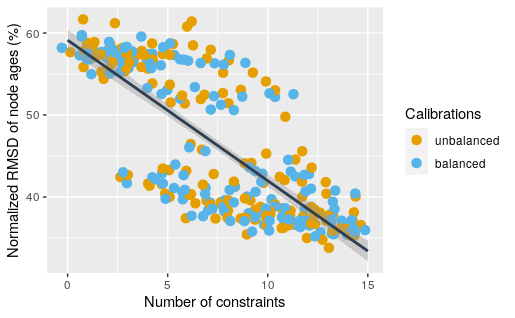

```r
library(ggplot2)

#Create a custom color scale
myColors <- c(y="#E69F00",n="#56B4E9")
names(myColors) <- levels(d$balanced)
colScale <- scale_colour_manual(name = "Calibrations",values = myColors)

ggplot(d, aes(x=numCons, y=rmsd_norm, colour = balanced)) +
  geom_point(size = 3, position="jitter") +
  colScale +
  geom_smooth(method=lm, color='#2C3E50') +
  labs(x="Number of constraints", y="Normalized RMSD of node ages (%)")+
  scale_fill_discrete("")
```

## Fraction of dates in 95% HPD

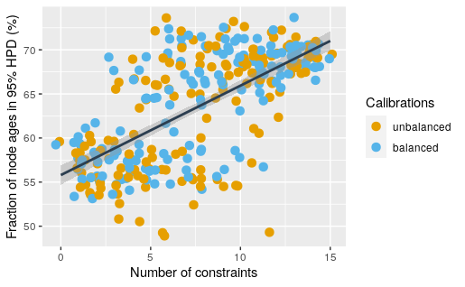

```r
ggplot(d, aes(x=numCons, y=fracInHPD, colour = balanced)) +
  geom_point(size = 3, position="jitter") +
  colScale +
  geom_smooth(method=lm, color='#2C3E50') +
  labs(x="Number of constraints", y="Fraction of node ages in 95% HPD (%)")
```

## Median size of the 95% HPD

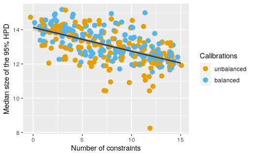

```r
ggplot(d, aes(x=numCons, y=percent50, colour = balanced)) +
  geom_point(size = 3, position="jitter") +
  colScale +
  geom_smooth(method=lm, color='#2C3E50') +
  labs(x="Number of constraints", y="Median size of the 95% HPD")
```

```r
#
```

# Linear models

## Model with the total number of constraints as explanatory variable

```r
mod_sum <- lm(formula("rmsd_norm ~ numCons"), data=d)
```

```r
summary(mod_sum)
```

```
Call:
lm(formula = formula("rmsd_norm ~ numCons"), data = d)

Residuals:
     Min       1Q   Median       3Q      Max
-12.3065  -3.6466   0.4649   3.3887  12.6629

Coefficients:
            Estimate Std. Error t value Pr(>|t|)
(Intercept)  59.1350     0.6417   92.15   <2e-16 ***
numCons      -1.7154     0.0751  -22.84   <2e-16 ***
---
Signif. codes:  0 ‘***’ 0.001 ‘**’ 0.01 ‘*’ 0.05 ‘.’ 0.1 ‘ ’ 1

Residual standard error: 5.431 on 310 degrees of freedom
Multiple R-squared:  0.6273,    Adjusted R-squared:  0.6261
F-statistic: 521.7 on 1 and 310 DF,  p-value: < 2.2e-16
```

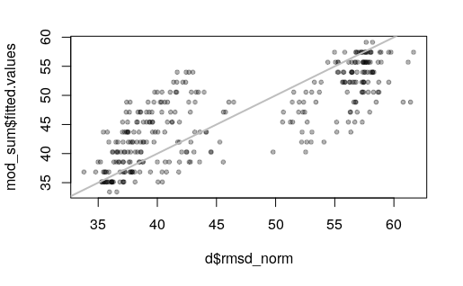

```r
plot(d$rmsd_norm, mod_sum$fitted.values, pch=20, col=rgb(0,0,0,0.3))
abline(a=0, b=1, col="grey", lwd=2)
```

## Does it help to include whether the calibrations are balanced or not?

```r
mod_sum_balanced <- lm(formula("rmsd_norm ~ numCons + balanced"), data=d)
```

```r
summary(mod_sum_balanced)
```

```
Call:
lm(formula = formula("rmsd_norm ~ numCons + balanced"), data = d)

Residuals:
    Min      1Q  Median      3Q     Max
-12.228  -3.659   0.458   3.429  12.741

Coefficients:
                 Estimate Std. Error t value Pr(>|t|)
(Intercept)      59.21323    0.71266  83.087   <2e-16 ***
numCons          -1.71542    0.07521 -22.807   <2e-16 ***
balancedbalanced -0.15641    0.61590  -0.254      0.8
---
Signif. codes:  0 ‘***’ 0.001 ‘**’ 0.01 ‘*’ 0.05 ‘.’ 0.1 ‘ ’ 1

Residual standard error: 5.439 on 309 degrees of freedom
Multiple R-squared:  0.6274,    Adjusted R-squared:  0.6249
F-statistic: 260.1 on 2 and 309 DF,  p-value: < 2.2e-16
```

No, it does not!

## Model with individual constraints as explanatory variables

### generate the formula

```r
xs <- paste0(colnames(d)[20:34], collapse=" + ")
y <- "rmsd_norm"
formul <- formula(paste (y, xs, sep="~"))
```

## Run the regression

```r
model <- lm(formul, data=d)
```

```r
summary(model)
```

```
Call:
lm(formula = formul, data = d)

Residuals:
    Min      1Q  Median      3Q     Max
-9.2397 -1.3630  0.0986  1.4347  7.9446

Coefficients:
            Estimate Std. Error t value Pr(>|t|)
(Intercept) 58.67468    0.39181 149.753  < 2e-16 ***
C_11         0.18299    0.41681   0.439  0.66096
C_41        -1.05674    0.43778  -2.414  0.01639 *
C_61        -5.54345    0.46212 -11.996  < 2e-16 ***
C_91         0.23329    0.40126   0.581  0.56142
C_121       -1.05895    0.39544  -2.678  0.00782 **
C_71        -2.00797    0.45932  -4.372 1.71e-05 ***
C_101       -0.63583    0.44652  -1.424  0.15551
C_131       -4.43446    0.46553  -9.526  < 2e-16 ***
C_151       -0.18633    0.48471  -0.384  0.70094
C_21        -1.73700    0.41306  -4.205 3.46e-05 ***
C_31         0.77975    0.39287   1.985  0.04809 *
C_51        -9.09489    0.41448 -21.943  < 2e-16 ***
C_81         0.07218    0.43420   0.166  0.86808
C_141        1.08866    0.46058   2.364  0.01874 *
C_111       -0.82420    0.44823  -1.839  0.06695 .
---
Signif. codes:  0 ‘***’ 0.001 ‘**’ 0.01 ‘*’ 0.05 ‘.’ 0.1 ‘ ’ 1

Residual standard error: 2.626 on 296 degrees of freedom
Multiple R-squared:  0.9168,    Adjusted R-squared:  0.9126
F-statistic: 217.4 on 15 and 296 DF,  p-value: < 2.2e-16
```

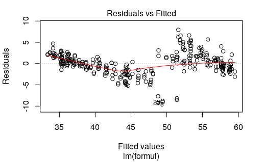

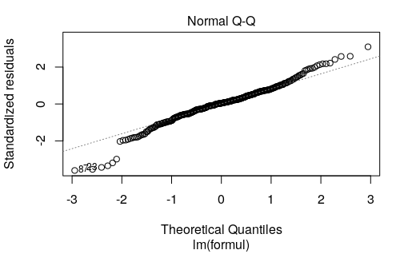

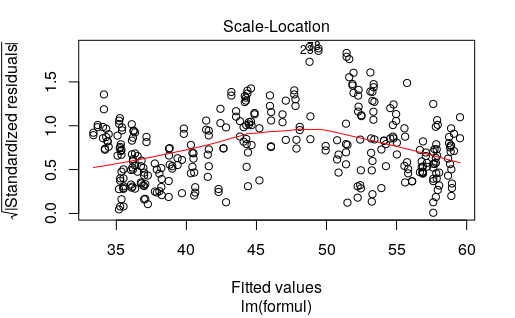

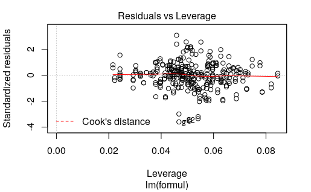

```r
plot(model)
```

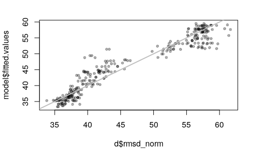

```r
plot(d$rmsd_norm, model$fitted.values, pch=20, col=rgb(0,0,0,0.3))
abline(a=0, b=1, col="grey", lwd=2)
```

### Using jtools https://cran.r-project.org/web/packages/jtools/vignettes/summ.html

```
Failed with error:  ‘there is no package called ‘broom.mixed’’
Failed with error:  ‘there is no package called ‘broom.mixed’’
```

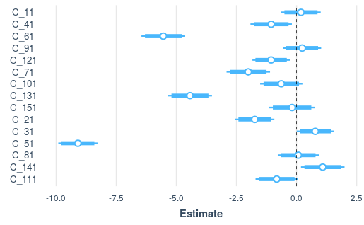

```r
library(jtools)
plot_summs(model, scale = FALSE, inner_ci_level = .9)
```

The most informative constraints are read from left to right. These are numbers 5, 6, 13. Looking at the summary: - including constraint 5 on average reduces the RMSD by 9.1% - including constraint 6 on average reduces the RMSD by 5.5% - including constraint 13 on average reduces the RMSD by 4.4%

The least informative ones are 14 and 3.

Same plot, controlling what I do:

```r
std_errors_times_2 <- 2 * summary(model)$coefficients[, 2][2:16]

par(mar=c(4, 5, 2, 1) + 0.1)
plot(constraint_numbers, model$coefficients[2:16], ylab='Contribution of the constraint\nto normalized RMSD', xlab='Constraint', ylim=c(-11, 2), xaxt="n")
axis(side=1, col="black", at=constraint_numbers, labels=constraint_numbers)
```

```r
at = axTicks(1)
mtext("Constraint", side=1, las=0, line = 3)
text(1:15, -11, labels=c("", "*", "", "", "*", "*", "*", "", "", "", "", "*", "*", "", ""), cex=2)
```

```r
abline(a=0, b=0, lwd=2, col="grey", lty=2)
arrows(x0=constraint_numbers, y0=model$coefficients[2:16] - std_errors_times_2, x1=constraint_numbers, y1=model$coefficients[2:16] + std_errors_times_2, code=3, angle=90, length=0.02, col="black", lwd=2)
```

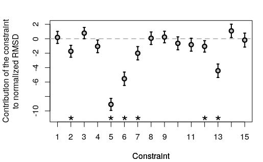

```r
points(constraint_numbers, model$coefficients[2:16], pch=20, cex=2, col="black")
points(constraint_numbers, model$coefficients[2:16], pch=20, cex=1, col="grey")
```

## Are there constraints present in the experiments with rmsd_norm <48 and not in those with rmsd_norm > 48?

```r
summary(d[which (d$rmsd_norm > 48),20:34])
```

```
 C_1    C_4    C_6     C_9    C_12    C_7    C_10   C_13   C_15   C_2
 0:72   0:54   0:110   0:74   0:106   0:72   0:94   0:92   0:94   0:122
 1:58   1:76   1: 20   1:56   1: 24   1:58   1:36   1:38   1:36   1:  8
 C_3    C_5     C_8     C_14   C_11
 0:76   0:130   0:116   0:94   0:114
 1:54   1:  0   1: 14   1:36   1: 16
```

```r
summary(d[which (d$rmsd_norm <= 48),20:34])
```

```
 C_1     C_4     C_6     C_9     C_12   C_7     C_10    C_13    C_15
 0: 62   0: 30   0: 22   0: 46   0:96   0: 60   0: 52   0: 32   0: 50
 1:120   1:152   1:160   1:136   1:86   1:122   1:130   1:150   1:132
 C_2    C_3     C_5     C_8     C_14   C_11
 0:90   0: 74   0: 40   0: 68   0:88   0:110
 1:92   1:108   1:142   1:114   1:94   1: 72
```

## What makes constraints informative?

Loading statistics on the constraints

```r
dcons<-read.table("statisticsOnConstraints.tsv", h=T)
dcons$informativeness <- model$coefficients[2:length(model$coefficients)]

dconsBL<-read.table("statisticsOnConstraintsOnBLTree.tsv", h=T)
dconsBL$informativeness <- model$coefficients[2:length(model$coefficients)]
```

```r
#model_informativeness <- lm(dcons$informativeness ~ dcons$o_age + dcons$y_age + dcons$delta_age + dcons$delta_nodes + dcons$delta_dist + dcons$across_the_root )
model_informativeness <- lm(dcons$informativeness ~ dcons$delta_age + dcons$delta_nodes + dcons$delta_dist + dcons$across_the_root +  dcons$num_leaves_younger + dcons$num_leaves_older + dcons$num_ancestors_younger + dcons$num_ancestors_older  )

summary(model_informativeness )
```

```
Call:
lm(formula = dcons$informativeness ~ dcons$delta_age + dcons$delta_nodes +
    dcons$delta_dist + dcons$across_the_root + dcons$num_leaves_younger +
    dcons$num_leaves_older + dcons$num_ancestors_younger + dcons$num_ancestors_older)

Residuals:
     Min       1Q   Median       3Q      Max
-1.84457 -0.57901 -0.00243  0.94715  1.31043

Coefficients:
                            Estimate Std. Error t value Pr(>|t|)
(Intercept)                 -0.31063    2.96544  -0.105   0.9200
dcons$delta_age             -0.38123    0.38658  -0.986   0.3621
dcons$delta_nodes           -0.30421    0.25742  -1.182   0.2820
dcons$delta_dist             0.10371    0.04641   2.235   0.0668 .
dcons$across_the_rootTrue   -0.98847    2.27352  -0.435   0.6789
dcons$num_leaves_younger    -0.13206    0.03987  -3.312   0.0162 *
dcons$num_leaves_older       0.05669    0.04501   1.260   0.2546
dcons$num_ancestors_younger  0.02135    0.32453   0.066   0.9497
dcons$num_ancestors_older   -0.04034    0.23680  -0.170   0.8703
---
Signif. codes:  0 ‘***’ 0.001 ‘**’ 0.01 ‘*’ 0.05 ‘.’ 0.1 ‘ ’ 1

Residual standard error: 1.579 on 6 degrees of freedom
Multiple R-squared:  0.8593,    Adjusted R-squared:  0.6717
F-statistic: 4.581 on 8 and 6 DF,  p-value: 0.03997
```

```r
summ(model_informativeness)
```

```
MODEL INFO:
Observations: 15
Dependent Variable: dcons$informativeness
Type: OLS linear regression

MODEL FIT:
F(8,6) = 4.58, p = 0.04
R² = 0.86
Adj. R² = 0.67

Standard errors: OLS
----------------------------------------------------------------
                                     Est.   S.E.   t val.      p
--------------------------------- ------- ------ -------- ------
(Intercept)                         -0.31   2.97    -0.10   0.92
dcons$delta_age                     -0.38   0.39    -0.99   0.36
dcons$delta_nodes                   -0.30   0.26    -1.18   0.28
dcons$delta_dist                     0.10   0.05     2.23   0.07
dcons$across_the_rootTrue           -0.99   2.27    -0.43   0.68
dcons$num_leaves_younger            -0.13   0.04    -3.31   0.02
dcons$num_leaves_older               0.06   0.05     1.26   0.25
dcons$num_ancestors_younger          0.02   0.32     0.07   0.95
dcons$num_ancestors_older           -0.04   0.24    -0.17   0.87
----------------------------------------------------------------
```

```r
#model_informativeness <- lm(dcons$informativeness ~ dcons$o_age + dcons$y_age + dcons$delta_age + dcons$delta_nodes + dcons$delta_dist + dcons$across_the_root )
model_informativenessBL <- lm(dconsBL$informativeness ~ dconsBL$delta_depth + dconsBL$delta_nodes + dconsBL$delta_dist + dconsBL$across_the_root + dconsBL$num_leaves_older + dconsBL$num_leaves_younger + dconsBL$num_ancestors_older + dconsBL$num_ancestors_younger)

summary(model_informativenessBL )
```

```
Call:
lm(formula = dconsBL$informativeness ~ dconsBL$delta_depth +
    dconsBL$delta_nodes + dconsBL$delta_dist + dconsBL$across_the_root +
    dconsBL$num_leaves_older + dconsBL$num_leaves_younger + dconsBL$num_ancestors_older +
    dconsBL$num_ancestors_younger)

Residuals:
    Min      1Q  Median      3Q     Max
-2.2361 -0.8461  0.1612  0.6826  1.9776

Coefficients:
                              Estimate Std. Error t value Pr(>|t|)
(Intercept)                    0.25011    3.57411   0.070   0.9465
dconsBL$delta_depth            3.25188    9.03763   0.360   0.7313
dconsBL$delta_nodes           -0.13913    0.24888  -0.559   0.5964
dconsBL$delta_dist             7.64632    6.07425   1.259   0.2549
dconsBL$across_the_rootTrue   -1.87120    2.68133  -0.698   0.5114
dconsBL$num_leaves_older       0.08468    0.05912   1.432   0.2020
dconsBL$num_leaves_younger    -0.14233    0.04571  -3.114   0.0207 *
dconsBL$num_ancestors_older   -0.01430    0.28309  -0.051   0.9613
dconsBL$num_ancestors_younger -0.19219    0.37543  -0.512   0.6270
---
Signif. codes:  0 ‘***’ 0.001 ‘**’ 0.01 ‘*’ 0.05 ‘.’ 0.1 ‘ ’ 1

Residual standard error: 1.9 on 6 degrees of freedom
Multiple R-squared:  0.7961,    Adjusted R-squared:  0.5243
F-statistic: 2.929 on 8 and 6 DF,  p-value: 0.1037
```

The model explains less variation when the data has been collected on the BL tree. Let’s look into deviations from clocklikeness.

```r
dconsBL$o_deviation <- dconsBL$o_depth * 100 - dcons$o_age
dconsBL$y_deviation <- dconsBL$y_depth * 100 - dcons$y_age
dconsBL$delta_deviation <- dconsBL$o_deviation - dconsBL$y_deviation
```

```r
#model_informativeness <- lm(dcons$informativeness ~ dcons$o_age + dcons$y_age + dcons$delta_age + dcons$delta_nodes + dcons$delta_dist + dcons$across_the_root )
model_informativenessBL <- lm(dconsBL$informativeness ~ dconsBL$delta_deviation + dconsBL$delta_nodes + dconsBL$delta_dist + dconsBL$across_the_root + dconsBL$num_leaves_older + dconsBL$num_leaves_younger )

summary(model_informativenessBL )
```

```
Call:
lm(formula = dconsBL$informativeness ~ dconsBL$delta_deviation +
    dconsBL$delta_nodes + dconsBL$delta_dist + dconsBL$across_the_root +
    dconsBL$num_leaves_older + dconsBL$num_leaves_younger)

Residuals:
    Min      1Q  Median      3Q     Max
-2.1410 -0.9189  0.2238  0.7756  2.3856

Coefficients:
                            Estimate Std. Error t value Pr(>|t|)
(Intercept)                 -0.82655    1.86345  -0.444  0.66911
dconsBL$delta_deviation      0.04391    0.08406   0.522  0.61559
dconsBL$delta_nodes         -0.19785    0.15872  -1.247  0.24784
dconsBL$delta_dist           7.20834    4.71527   1.529  0.16486
dconsBL$across_the_rootTrue -0.89228    1.85021  -0.482  0.64254
dconsBL$num_leaves_older     0.07924    0.04380   1.809  0.10802
dconsBL$num_leaves_younger  -0.13746    0.03846  -3.574  0.00726 **
---
Signif. codes:  0 ‘***’ 0.001 ‘**’ 0.01 ‘*’ 0.05 ‘.’ 0.1 ‘ ’ 1

Residual standard error: 1.666 on 8 degrees of freedom
Multiple R-squared:  0.791, Adjusted R-squared:  0.6343
F-statistic: 5.046 on 6 and 8 DF,  p-value: 0.01988
```

## Where did we get the best improvement?

```r
which(d$rmsd_norm[2:length(d$rmsd_norm)] - d$rmsd_norm[1:(length(d$rmsd_norm)-1)] == min(d$rmsd_norm[2:length(d$rmsd_norm)] - d$rmsd_norm[1:(length(d$rmsd_norm)-1)]))
```

```
[1] 221
```

–> line 222 has the best improvement over line 221.

```r
d[221,]
```

|  | TreeId | numCalib | numCons | balanced | old_biased | correlation | rmsd | rmsd_norm | cor_bls | rmsd_bls | num_nodes | numInHPD | fracInHPD | percent0 | percent25 | percent50 | percents75 | percent100 | rep | C_1 | C_4 | C_6 | C_9 | C_12 | C_7 | C_10 | C_13 | C_15 | C_2 | … |
| --- | --- | --- | --- | --- | --- | --- | --- | --- | --- | --- | --- | --- | --- | --- | --- | --- | --- | --- | --- | --- | --- | --- | --- | --- | --- | --- | --- | --- | --- | --- |
| 221 | 6_2_cons_BD | 10 | 2 | balanced | y | 0.58469 | 7.724079 | 58.92676 | 0.2315222 | 5.494028 | 101 | 56 | 55.44554 | 6.72579 | 11.33704 | 13.28459 | 16.4699 | 20.9199 | 6 | 0 | 0 | 1 | 1 | 0 | 0 | 0 | 0 | 0 | 0 | … |

```r
d[222,]
```

|  | TreeId | numCalib | numCons | balanced | old_biased | correlation | rmsd | rmsd_norm | cor_bls | rmsd_bls | num_nodes | numInHPD | fracInHPD | percent0 | percent25 | percent50 | percents75 | percent100 | rep | C_1 | C_4 | C_6 | C_9 | C_12 | C_7 | C_10 | C_13 | C_15 | C_2 | … |
| --- | --- | --- | --- | --- | --- | --- | --- | --- | --- | --- | --- | --- | --- | --- | --- | --- | --- | --- | --- | --- | --- | --- | --- | --- | --- | --- | --- | --- | --- | --- |
| 222 | 6_3_cons_BD | 10 | 3 | balanced | y | 0.7624643 | 5.505555 | 41.68228 | 0.1896636 | 5.476294 | 101 | 68 | 67.32673 | 6.50529 | 10.19188 | 12.95664 | 14.57406 | 20.44549 | 6 | 0 | 0 | 1 | 1 | 0 | 0 | 0 | 0 | 0 | 0 | … |

```r
NA
```

Replicate 6, moving from 2 to 3 constraints.

### Let’s look at the trees

```r
library(ape)
t_6_2 <- read.nexus(file="OutputDatingRandomOrder/Rep_6/Cal_10_y_y_Cons_2_cons_BD_UGAMr_BL_MC3.tree")
t_6_3 <- read.nexus(file="OutputDatingRandomOrder/Rep_6/Cal_10_y_y_Cons_3_cons_BD_UGAMr_BL_MC3.tree")
true_tree <- read.tree(file="SimulatedTrees/proposedTree.dnd")
```

[output not shown]

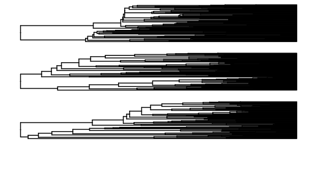

```r
library(ggplot2)
library("ggtree")
ptrue <- ggtree(true_tree)
p1 <- ggtree(t_6_2)
p2 <- ggtree(t_6_3)

multiplot(ptrue, p1, p2, nrow=3, ncol=1)
```